# Metapangenomic analysis of *Staphylococcus aureus* in inflammatory skin diseases

Online Supplementary Material for Poster Presentation [ECCB 2024](https://eccb2024.fi/)

Zoltán Rádai$^{1,2}$, Péter Oláh$^{1,3}$, Jos Smits$^{1,4}$, EU-MAARS Consortium$^5$, Bernhard Homey$^1$

1. Department of Dermatology, University Hospital Duesseldorf, Medical Faculty, Heinrich-Heine University Duesseldorf, Germany
2. One Health Institute, Faculty of Health Sciences, University of Debrecen, Hungary
3. Department of Dermatology, Venereology and Oncodermatology, Medical Faculty, University of Pécs, Hungary
4. Department of Dermatology, Radboud Research Institute for Medical Innovation, Radboud University Medical Center, Nijmegen, The Netherlands
5. The EU-MAARS Consortium, Helsinki, Finland

This online supplementary material provides some additional details and information about the presented metapangenomic workflow. This workflow utilizes 22 reference genomes of *Staphylococcus aureus* and 281 whole metagenome sequencing (WMS) samples originating from lesional (LS) and non-lesional (NL) skin sites of patients with active atopic dermatitis (AD) or psoriasis (PSO), as well as from healthy volunteers (HV).

Our workflow relied on:

- *metaSPAdes* [(Nurk et al., 2017)](https://genome.cshlp.org/content/27/5/824.short): clinical groupwise co-meta-assemblies,
- *kraken2* [(Wood et al., 2019)](https://doi.org/10.1186/s13059-019-1891-0): taxonomical classification of co-meta-assembly contigs,
- *samtools* [(Li et al., 2009)](https://doi.org/10.1093/bioinformatics/btp352) & *bwa* [(Li 2013)](https://arxiv.org/abs/1303.3997): read mapping,
- *DFAST* [(Tanizawa et al., 2017)](https://doi.org/10.1093/bioinformatics/btx713): reference genome annotation,
- *CD-HIT* [(Fu et al., 2012)](https://doi.org/10.1093/bioinformatics/bts565): clustering proteins,
- *eggNOG mapper* [(Cantalapiedra et al., 2021)](https://doi.org/10.1093/molbev/msab293): functional annotation and biological function descriptions for proteins,
- *Anvi’o* [(Eren et al., 2021)](https://doi.org/10.1038/s41564-020-00834-3): pangenomic analysis and visualization,
- *R* [(R Core team, 2013)](https://apps.dtic.mil/sti/citations/AD1039033): data handling, analyses, and visualization.

# Poster Legends

## 3A

### Radar plot (upper left)

Summarizing results of *kraken2* classification of contigs from groupwise co-meta-assemblies across clinical groups. On the labels, the numbers in parentheses denote the min-max range of observed values.

**Note:** cf. supplementary figure S1 on the same metrics for contigs classified to belong to *Butyricimonas virosa*.

### Bar plots (lower left)

Bar plot visualization of the same data as on the radar plot.

### Forest plot (right)

Estimated marginal contrasts (EMCs) from the ordered Beta GLMMs (see Genomic Coverage and Detection for details) for coverage of reference genomes by WMS samples. Comparisons are always made to HV, hence positive *vs.* negative EMCs indicate increased *vs.* decreased coverage of given clinical group, respectively (e.g. AD-LS: atopic dermatitis lesional samples), in comparison to HV.

## 3B

Composite visualization of gene clusters in reference genomes (from the *Anvi’o* pangenomic workflow [(Delmont et al., 2018)](https://doi.org/10.7717/peerj.4320)) and the genomes’ coverage (re-scaled samplewise by sample max) by WMS samples. The concentric circles represent (from out to inward):

- bar plot: number of genomes showing hits for the given cluster,
- bar plot: number of genes in the cluster,
- bar plot: protein geometric homogeneity; an index in the range from 0 (completely heterogeneous) to 1 (completely homogeneous), informing on homogeneity of gap/residue distributions based on the multiple alignments,
- bar plot: protein functional homogeneity; an index in the range from 0 (completely heterogeneous) to 1 (completely homogeneous), informing on similarity in amino acid physicochemical properties between cluster residues in the alignments,
- dark *vs.* light blue band: denoting presence (dark blue) or absence (light blue) of single copy core genes (scCG),
- 22 concentric circles dark/light bands: denoting presence (dark colours) or absence (light colours) of gene clusters in the 22 *S. aureus* reference genomes.

Genomes are positioned based on the phylogenetic tree built (with *fasttree* [(Price et al., 2009)](https://doi.org/10.1093/molbev/msp077)) using the gene clusters of variable (0 < homogeneity < 1) single copy core genes.

The heatmap is showing the samplewise max-re-scaled coverage values of WMS data on the reference genomes; rows and columns represent samples and reference genomes, respectively, and each column is positioned exactly to the corresponding reference genome on the pangenomic display.

## 4

### Heatmap (upper left)

Heatmap showing unique bacterial proteins (rows) that are significantly positively associated with disease severity in AD-LS, being present (yellow) or absent (black) in the reference genomes (columns). Protein name labels are shown for proteins which are among the largest effect size and largest significance ones, alongside with serine protease-like proteins (SplA, SplB, SplC, SplD, SplF) found throughout our analyses.

### Volcano plot (upper right)

Scatter plot showing estimated marginal trends (EMTs, a.k.a. regression slope parameter estimates: horizontal axis) from the GLMs on the association between protein presences and AD-LS severity (quantified by SCORAD, see corresponding section) *vs.* significance ($-log_{10}(p)$: vertical axis) of estimates. Protein name labels are shown for proteins which are among the largest effect size and largest significance ones. For some proteins multiple variants (`var`) were found, hence these were denoted with variant counters (e.g. `cydC: var 1`). Colour coding shows effect sizes calculated as the p-value-weighted absolute EMT ($S = |EMT| × (1-p)$); dot sizes are proportional to the absolute value of EMT, and dot shapes denote pathogenesis core (PCG: gene present in >25% of samples), accessory (PAG: gene present in 5-25% of samples), and rare (gene present in <5% of samples) groups (PCAG: see description on core genes).

### Heatmap (lower right)

Heatmap showing the distribution of detection values (see Genomic Coverage and Detection) for unique bacterial proteins (columns) in AD-LS samples (rows). This representation visualizes how AD-LS samples diverge based on their bacterial protein detection rates (i.e. practically by the presence of *S. aureus*), samples with large detection of proteins being associated with higher disease severity (larger SCORAD scores). This is consistent with past observations that (i) *S. aureus* does not appear to be always present in AD-LS skin, but (ii) when it is, it often exacerbates disease severity. It is also clear that the overwhelming majority of severity-associated proteins were identified as accessory (RAG: reference accessory gene) across the studied reference genomes (see description on core and accessory genes).

### Contingency table (lower left)

Contingency table summarizing protein group occurrences from a dual perspective, namely:

- from the perspective of the reference genomes (i.e. **pangenomic** perspective): based on the *Anvi’o* pangenomics workflow there were 2402 accessory genes (RAG), and 72 single copy core genes (scCG),
- from the perspective of the WMS samples (i.e. **metagenomic** perspective): based on the protein-severity GLMs there were 53 rare unique protein coding genes (being present in maximum 5% of AD samples), 369 genes that we refer to as “pathogenesis accessory genes” (PAG: genes present in 5-25% of AD samples), and 2052 pathogenesis core genes (PCG: genes present in >25% of AD samples).

This double categorization approach helps us to have a more nuanced separation between proteins in terms of their presence in *S. aureus* strains and biomedical importance in affecting disease severity. Indeed, our results provide strong metapangenomic support for recent findings of *S. aureus* virulence being determined by accessory genome and mobilome, and no genotype or genomic content appears to be uniquely associated with AD [(Conte et al., 2023)](https://doi.org/10.3389/fcimb.2023.1194254).

# Supplementary Figures

## Contig classification for the gut microbe *Butyricimonas virosa*

To confirm that the *kraken2*-based contig identifications indeed suggest the true presence of *S. aureus* (even if in very minute abundances, i.e. with low samplewise detectability), we also checked contig classification results for *Butyricimonas virosa*, a common gut microbe, which is not part of either the normal or inflammatory skin microbiome. Much smaller contig counts and total contig lengths for *B. virosa* than for *S. aureus* are consistent with expected dynamics, i.e. *B. virosa* likely being absent whereas *S. aureus* being present in the groupwise skin pan-microbiomes.

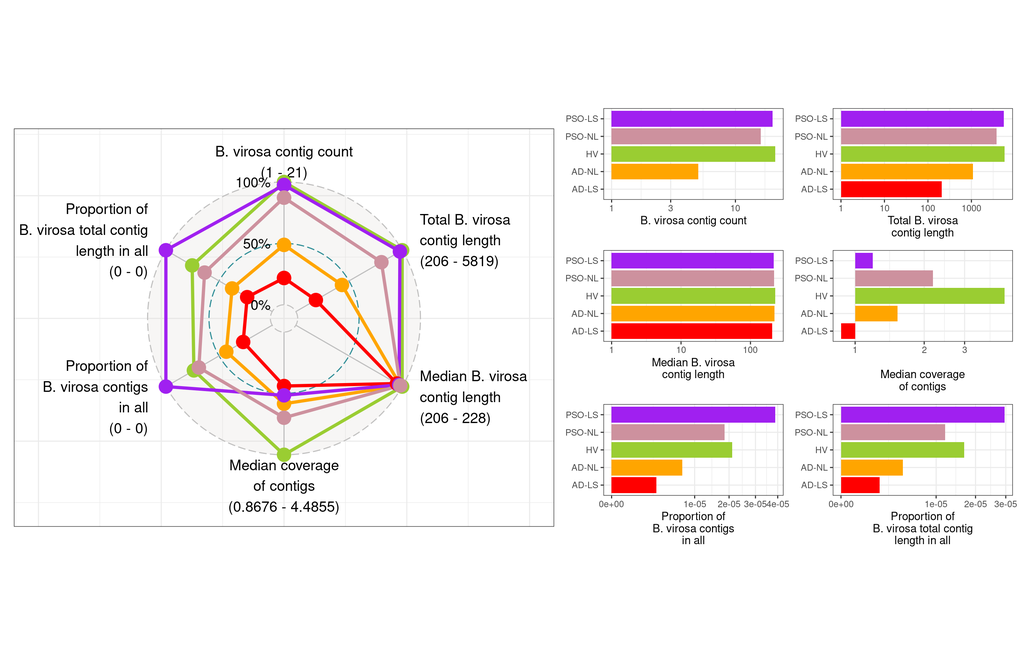

## Differential Detection

Unlike in the case of coverage, statistical significance was assessed based on EMC p-values (see corresponding section for details), using the ~$3 \sigma$ threshold ($\alpha = 0.003$).

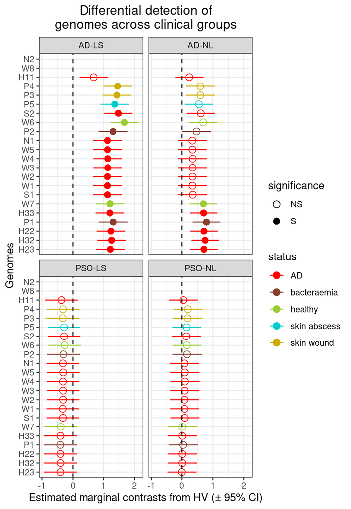

# Genome Data

Some of the *Staphylococcus aureus* reference genomes were obtained from [PubMLST](https://pubmlst.org/), and [NCBI-RefSeq](https://www.ncbi.nlm.nih.gov/datasets/genome/) (see `genome_source` in the genome table below); some isolate assemblies were obtained from among those published by [Wang et al. (2022)](https://doi.org/10.1128/mra.00072-22); in addition, we included yet-unpublished hybrid assemblies originating from AD lesions, isolate and sequenced at the University Hospital Düsseldorf, Germany (genomes tagged **Homey** and **Smits**).

|  | ID | genome_source | country | bio_source | anatomical_location | status | genome_size | GC | contig_number | N50 | L50 | number_of_Ns | lesional |
| --- | --- | --- | --- | --- | --- | --- | --- | --- | --- | --- | --- | --- | --- |
| P5 | pubmlst_39195 | pubMLST | Denmark | skin |  | skin abscess | 2846546 | 32.8765106905 | 1 | 2846546 | 1 | 0 |  |
| P4 | pubmlst_36408 | pubMLST | Germany | skin |  | skin wound | 2780979 | 32.6723790434951 | 33 | 186850 | 5 | 0 |  |
| P3 | pubmlst_36407 | pubMLST | Germany | skin |  | skin wound | 2812015 | 32.7137301899172 | 34 | 160969 | 6 | 0 |  |
| P2 | pubmlst_34339 | pubMLST | Germany | blood |  | bacteraemia | 2726253 | 32.7149387822774 | 24 | 243570 | 4 | 384 |  |
| P1 | pubmlst_33816 | pubMLST | Netherlands | blood |  | bacteraemia | 2763820 | 32.7368280134017 | 32 | 268105 | 4 | 254 |  |
| N2 | ncbi_GCF_020389325 | NCBI | Germany | skin | nose | healthy | 2719233 | 32.9602869632724 | 1 | 2719233 | 1 | 0 |  |
| N1 | ncbi_GCF_020386595 | NCBI | Germany | skin | nose | AD | 2766978 | 32.9130914665747 | 1 | 2766978 | 1 | 0 |  |
| H11 | Homey_isolate_11 | Homey | Germany | skin |  | AD | 2891169 | 32.7972871872934 | 2 | 2862144 | 1 | 0 | LS |
| H22 | Homey_isolate_22 | Homey | Germany | skin |  | AD | 2731113 | 32.9028494976224 | 1 | 2731113 | 1 | 0 | LS |
| H23 | Homey_isolate_23 | Homey | Germany | skin |  | AD | 2725282 | 32.8870186644905 | 2 | 2696262 | 1 | 0 | LS |

[output cut: 12 more lines]

# Genomic Coverage and Detection

Throughout our study we consistently used **coverage** as the mean number of reads across the genomes’ base positions in a given sample:

$$c_G = \frac{r_{sG}}{l_G}$$
where $r_{sG}$ is the total number of reads from sample $s$ mapped onto genome $G$, and $l_G$ is the size (bp) of genome $G$.

**Detection** was defined as the proportion of bases in the genome covered by at least one read.

## Model fitting

Data was structured in long format to represent all *genome / WMS sample* combinations, i.e. so coverage, detection, clinical group, sample ID, genome ID, and weights (see later) were the variables (i.e. columns). Coverage values were re-scaled prior to model fitting by samplewise maximum, in order to aid model fitting and comparisons between samples:

$$c'_{sG} =
\frac{c_{sG}}{max(c_{G})}$$
where $c_{sG}$ is the coverage value for sample $s$ on the genome $G$, and $c_G$ is the array of all samples’ coverage values for genome $G$.

Ordered Beta generalized linear mixed-effects models (GLMM) were fitted for both coverage and detection, using the R-package `glmmTMB` [(Brooks et al. 2017)](https://doi.org/10.32614/RJ-2017-066); fixed predictors were the genome ID and clinical group (with explicit control for their interaction), and sample ID was specified as random effect:

```r
glmmTMB(
  y ~ genome * group + (1|sample),
  data = data, family = ordbeta(link = "logit"), REML = F, weights = w,
  control = glmmTMBControl(parallel = 10, optimizer = optim, optArgs = list(method="BFGS"))
)
```

where model weights (`w`) were calculated for each sample as the sample’s log-transformed filtered library size divided by the log-transformed maximum library size across samples:

$$w_s =
\frac{ln(R_s)}{ln(R_{max})}$$
Both for coverage and detection differential dynamics were assessed by extracting the estimated mean contrasts (EMC) between each pair if non-healthy groups and healthy group (e.g. AD-LS *vs.* HV), marginalized separately for each genome.

Since EMCs are not independent across groups, we used Stouffer’s z-value calculation to estimate combined statistical significance for differential coverage (i.e. clinical groupwise differences from HV), separately for each genome:

$$z_G = \frac{\sum_i^n z_{Gi}}{ \sqrt{n}
}$$
where $i$ indexes clinical groups across $n$ groups (4 in our case: AD-LS, AD-NL, PSO-NL, PSO-LS). This meta-analytic approach helps to identify consistent patterns based on both directionality and effect size of EMCs.

# Significant-effect Proteins in AD-LS

Association between AD severity and presence of unique bacterial proteins was assessed. For clinical severity, the **local intensity SCORAD** score was used. It is is calculated as follows:

- *Assessment of Intensity Criteria:* the severity of six clinical signs is assessed within this selected area. Each sign is scored on a scale from 0 to 3:
  - 0: Absent
  - 1: Mild
  - 2: Moderate
  - 3: Severe
- *Six clinical signs:*
  - Erythema (redness),
  - Edema/papulation (swelling or formation of papules),
  - Oozing/crusts (presence of fluid or crusts),
  - Excoriation (scratch marks),
  - Lichenification (thickening of the skin),
  - Dryness (only scored if no acute lesions are present).
- *Calculation:* sum the scores of the six clinical signs. The total score can range from 0 to 18, which indicates the severity of AD in the sampled area.

## Model fitting

Presence of a protein in a given sample was defined based on the corresponding detection value ($d_{Ps}$, $P$ and $s$ referring to a given protein and a given sample, respectively), and the given protein’s size, by defining a detection threshold for each protein, above which it could be considered to be present:

$$t_P = t_0 + (1-t_0)e^{-l_P
\lambda}$$
where $t_P$ is the detection threshold for protein $P$ with the coding gene’s nucleotide sequence length being $l_P$, $t_0$ is a global minimum threshold (defined to be 0.5 in our analyses), and $\lambda$ is a rate parameter (defined to be 0.005). Hence, smaller proteins received more stringent detection thresholds, because if we assume close-to-uniform read mapping, they are more likely to be covered over larger sections relative to their size. Below is a visualization of the association between protein coding gene size and calculated detection threshold:

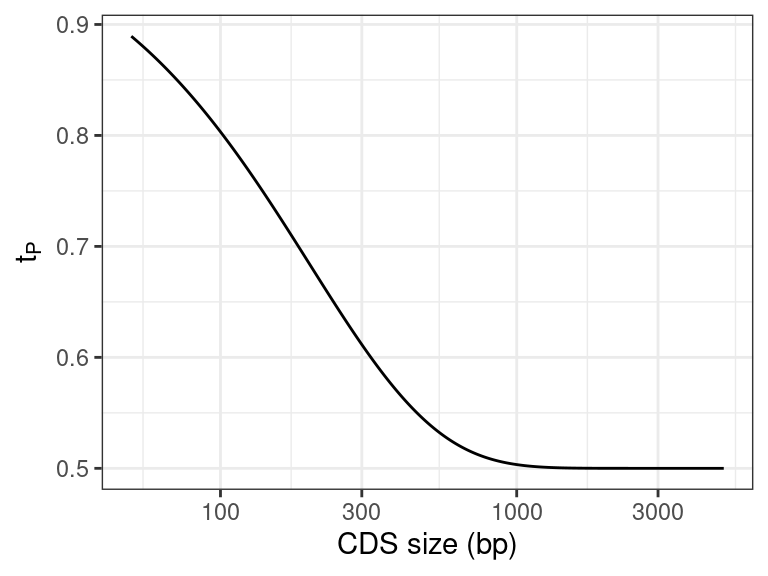

GLMs were fitted with `glmmTMB` as:

```r
glmmTMB(
  presence ~ SCORAD + I(log(lib_size)),
  family = "binomial", data = data
)
```

Statistical significance of proteins’ associations with bacterial genes were establsihed based on local false discovery rate ($FDR < 0.05$).

## Table of proteins

Below are those proteins which showed significant association with severity (SCORAD) in AD-LS; proteins are ordered based on the p-value-weighted absolute EMT ($S = |ß| × (1-p)$).

| name | description | COG_category | PCAG | scCG | estimate | p | lfdr | S |
| --- | --- | --- | --- | --- | --- | --- | --- | --- |
| ssaA | secretory antigen | S | PCG | RAG | 0.8738421491142861 | 0.004933662987917596 | 0.03460225745548138 | 0.8695309064459186 |
| psuG | Catalyzes the reversible cleavage of pseudouridine 5'- phosphate (PsiMP) to ribose 5-phosphate and uracil. Functions biologically in the cleavage direction, as part of a pseudouridine degradation path… | Q | PCG | RAG | 0.8757570989425967 | 0.01507041336396268 | 0.04856055965413511 | 0.8625590774551071 |
| rnjA | An RNase that has 5'-3' exonuclease and possibly endonuclease activity. Involved in maturation of rRNA and in some organisms also mRNA maturation and or decay | J | PCG | RAG | 0.859602054324657 | 0.006517102607790276 | 0.03460225745548138 | 0.8539999395347558 |
| atoB | Belongs to the thiolase family | I | PCG | RAG | 0.8619700473594804 | 0.01653624301238454 | 0.04856055965413511 | 0.8477163011869474 |
| pdxK | Phosphomethylpyrimidine kinase | H | PCG | RAG | 0.8619700473594804 | 0.01653624301238454 | 0.04856055965413511 | 0.8477163011869474 |
| - | Domain of unknown function DUF21 | P | PCG | RAG | 0.8619700473594804 | 0.01653624301238454 | 0.04856055965413511 | 0.8477163011869474 |
| dltB | membrane protein involved in D-alanine export | M | PCG | RAG | 0.8619700473594804 | 0.01653624301238454 | 0.04856055965413511 | 0.8477163011869474 |
| - | - | - | PCG | RAG | 0.8619700473594804 | 0.01653624301238454 | 0.04856055965413511 | 0.8477163011869474 |
| deoB | Phosphotransfer between the C1 and C5 carbon atoms of pentose | G | PCG | RAG | 0.8619700473594804 | 0.01653624301238454 | 0.04856055965413511 | 0.8477163011869474 |
| - | Staphylococcal superantigen-like OB-fold domain | S | PAG | RAG | 0.8619700473594804 | 0.01653624301238454 | 0.04856055965413511 | 0.8477163011869474 |

[output cut: 2464 more lines]

# References

- Brooks, M. E., Kristensen, K., Van Benthem, K. J., Magnusson, A., Berg, C. W., Nielsen, A., … & Bolker, B. M. (2017). glmmTMB balances speed and flexibility among packages for zero-inflated generalized linear mixed modeling. The R journal, 9(2), 378-400.
- Cantalapiedra, C. P., Hernández-Plaza, A., Letunic, I., Bork, P., & Huerta-Cepas, J. (2021). eggNOG-mapper v2: functional annotation, orthology assignments, and domain prediction at the metagenomic scale. Molecular biology and evolution, 38(12), 5825-5829.
- Conte, A. L., Brunetti, F., Marazzato, M., Longhi, C., Maurizi, L., Raponi, G., … & Conte, M. P. (2023). Atopic dermatitis-derived Staphylococcus aureus strains: what makes them special in the interplay with the host. Frontiers in Cellular and Infection Microbiology, 13, 1194254.
- Delmont, T. O., & Eren, A. M. (2018). Linking pangenomes and metagenomes: the Prochlorococcus metapangenome. PeerJ, 6, e4320.
- Eren, A. M., Kiefl, E., Shaiber, A., Veseli, I., Miller, S. E., Schechter, M. S., … & Willis, A. D. (2021). Community-led, integrated, reproducible multi-omics with anvi’o. Nature microbiology, 6(1), 3-6.
- Fu, L., Niu, B., Zhu, Z., Wu, S., & Li, W. (2012). CD-HIT: accelerated for clustering the next-generation sequencing data. Bioinformatics, 28(23), 3150-3152.
- Li, H., Handsaker, B., Wysoker, A., Fennell, T., Ruan, J., Homer, N., … & 1000 Genome Project Data Processing Subgroup. (2009). The sequence alignment/map format and SAMtools. bioinformatics, 25(16), 2078-2079.
- Li, H. (2013). Aligning sequence reads, clone sequences and assembly contigs with BWA-MEM. arXiv preprint arXiv:1303.3997.
- Nurk, S., Meleshko, D., Korobeynikov, A., & Pevzner, P. A. (2017). metaSPAdes: a new versatile metagenomic assembler. Genome research, 27(5), 824-834.
- Price, M. N., Dehal, P. S., & Arkin, A. P. (2009). FastTree: computing large minimum evolution trees with profiles instead of a distance matrix. Molecular biology and evolution, 26(7), 1641-1650.
- R Core Team, R. (2013). R: A language and environment for statistical computing. Tanizawa, Y., Fujisawa, T., & Nakamura, Y. (2018). DFAST: a flexible prokaryotic genome annotation pipeline for faster genome publication. Bioinformatics, 34(6), 1037-1039.
- Wang, Z., Hülpüsch, C., Schwierzeck, V., Alharbi, S. A., Reiger, M., Traidl-Hoffmann, C., … & Foesel, B. U. (2022). Complete and draft genome sequences of 48 staphylococcus aureus isolates obtained from atopic dermatitis patients and healthy controls. Microbiology Resource Announcements, 11(4), e00072-22.
- Wood, D. E., Lu, J., & Langmead, B. (2019). Improved metagenomic analysis with Kraken 2. Genome biology, 20, 1-13.